# Computational Math DATA 605 Final

Daniel Hong

December 20, 2016

The objective is to use the Ames dataset to participate in the Kaggle competition, House Prices: Advanced Regression Techniques. There are 79 explanatory variables describing (almost) every aspect of residential homes in Ames, Iowa and this competition challenges the participant to predict the final price of each home. Start by loading the required packages, these data and looking at some basic information, like completeness of the dataset, means, standard dviations, min and max values.

```r
require("plyr")
require("knitr")
require("psych")
require("reshape2")
```

```r
require("ggplot2")
require("MASS")
train <- read.csv(url('https://raw.githubusercontent.com/danielhong98/DATA-605/master/train.csv'))
test <- read.csv(url('https://raw.githubusercontent.com/danielhong98/DATA-605/master/test.csv'))

columns <- colnames(train)
columns
```

```
##  [1] "Id"            "MSSubClass"    "MSZoning"      "LotFrontage"
##  [5] "LotArea"       "Street"        "Alley"         "LotShape"
##  [9] "LandContour"   "Utilities"     "LotConfig"     "LandSlope"
## [13] "Neighborhood"  "Condition1"    "Condition2"    "BldgType"
## [17] "HouseStyle"    "OverallQual"   "OverallCond"   "YearBuilt"
## [21] "YearRemodAdd"  "RoofStyle"     "RoofMatl"      "Exterior1st"
## [25] "Exterior2nd"   "MasVnrType"    "MasVnrArea"    "ExterQual"
## [29] "ExterCond"     "Foundation"    "BsmtQual"      "BsmtCond"
## [33] "BsmtExposure"  "BsmtFinType1"  "BsmtFinSF1"    "BsmtFinType2"
## [37] "BsmtFinSF2"    "BsmtUnfSF"     "TotalBsmtSF"   "Heating"
## [41] "HeatingQC"     "CentralAir"    "Electrical"    "X1stFlrSF"
## [45] "X2ndFlrSF"     "LowQualFinSF"  "GrLivArea"     "BsmtFullBath"
## [49] "BsmtHalfBath"  "FullBath"      "HalfBath"      "BedroomAbvGr"
## [53] "KitchenAbvGr"  "KitchenQual"   "TotRmsAbvGrd"  "Functional"
## [57] "Fireplaces"    "FireplaceQu"   "GarageType"    "GarageYrBlt"
## [61] "GarageFinish"  "GarageCars"    "GarageArea"    "GarageQual"
## [65] "GarageCond"    "PavedDrive"    "WoodDeckSF"    "OpenPorchSF"
## [69] "EnclosedPorch" "X3SsnPorch"    "ScreenPorch"   "PoolArea"
## [73] "PoolQC"        "Fence"         "MiscFeature"   "MiscVal"
## [77] "MoSold"        "YrSold"        "SaleType"      "SaleCondition"
## [81] "SalePrice"
```

```r
target <- "SalePrice"
inputs <- columns[!columns %in% c(target,"ID")]

summary <- describe(train[,c(target,inputs)])[,c("n","mean","sd","median","max","min")]
summary$completeness <- summary$n/nrow(train)
kable(summary)
```

|  | n | mean | sd | median | max | min | completeness |
| --- | --- | --- | --- | --- | --- | --- | --- |
| SalePrice | 1460 | 1.809212e+05 | 7.944250e+04 | 163000.0 | 755000 | 34900 | 1.0000000 |
| Id | 1460 | 7.305000e+02 | 4.216100e+02 | 730.5 | 1460 | 1 | 1.0000000 |
| MSSubClass | 1460 | 5.689726e+01 | 4.230057e+01 | 50.0 | 190 | 20 | 1.0000000 |
| MSZoning* | 1460 | 4.028767e+00 | 6.320174e-01 | 4.0 | 5 | 1 | 1.0000000 |
| LotFrontage | 1201 | 7.004996e+01 | 2.428475e+01 | 69.0 | 313 | 21 | 0.8226027 |
| LotArea | 1460 | 1.051683e+04 | 9.981265e+03 | 9478.5 | 215245 | 1300 | 1.0000000 |
| Street* | 1460 | 1.995890e+00 | 6.399610e-02 | 2.0 | 2 | 1 | 1.0000000 |
| Alley* | 91 | 1.450549e+00 | 5.003052e-01 | 1.0 | 2 | 1 | 0.0623288 |
| LotShape* | 1460 | 2.942466e+00 | 1.409156e+00 | 4.0 | 4 | 1 | 1.0000000 |
| LandContour* | 1460 | 3.777397e+00 | 7.076659e-01 | 4.0 | 4 | 1 | 1.0000000 |
| Utilities* | 1460 | 1.000685e+00 | 2.617120e-02 | 1.0 | 2 | 1 | 1.0000000 |
| LotConfig* | 1460 | 4.019178e+00 | 1.622634e+00 | 5.0 | 5 | 1 | 1.0000000 |
| LandSlope* | 1460 | 1.062329e+00 | 2.762325e-01 | 1.0 | 3 | 1 | 1.0000000 |
| Neighborhood* | 1460 | 1.315000e+01 | 5.893512e+00 | 13.0 | 25 | 1 | 1.0000000 |
| Condition1* | 1460 | 3.031507e+00 | 8.685151e-01 | 3.0 | 9 | 1 | 1.0000000 |
| Condition2* | 1460 | 3.008219e+00 | 2.590399e-01 | 3.0 | 8 | 1 | 1.0000000 |
| BldgType* | 1460 | 1.493151e+00 | 1.198277e+00 | 1.0 | 5 | 1 | 1.0000000 |
| HouseStyle* | 1460 | 4.038356e+00 | 1.911305e+00 | 3.0 | 8 | 1 | 1.0000000 |
| OverallQual | 1460 | 6.099315e+00 | 1.382996e+00 | 6.0 | 10 | 1 | 1.0000000 |
| OverallCond | 1460 | 5.575342e+00 | 1.112799e+00 | 5.0 | 9 | 1 | 1.0000000 |
| YearBuilt | 1460 | 1.971268e+03 | 3.020290e+01 | 1973.0 | 2010 | 1872 | 1.0000000 |
| YearRemodAdd | 1460 | 1.984866e+03 | 2.064541e+01 | 1994.0 | 2010 | 1950 | 1.0000000 |
| RoofStyle* | 1460 | 2.410274e+00 | 8.349978e-01 | 2.0 | 6 | 1 | 1.0000000 |
| RoofMatl* | 1460 | 2.075343e+00 | 5.991268e-01 | 2.0 | 8 | 1 | 1.0000000 |
| Exterior1st* | 1460 | 1.062466e+01 | 3.197659e+00 | 13.0 | 15 | 1 | 1.0000000 |
| Exterior2nd* | 1460 | 1.133973e+01 | 3.540570e+00 | 14.0 | 16 | 1 | 1.0000000 |
| MasVnrType* | 1452 | 2.761019e+00 | 6.157107e-01 | 3.0 | 4 | 1 | 0.9945205 |
| MasVnrArea | 1452 | 1.036853e+02 | 1.810662e+02 | 0.0 | 1600 | 0 | 0.9945205 |
| ExterQual* | 1460 | 3.539726e+00 | 6.939946e-01 | 4.0 | 4 | 1 | 1.0000000 |
| ExterCond* | 1460 | 4.733562e+00 | 7.318072e-01 | 5.0 | 5 | 1 | 1.0000000 |

[output cut: 52 more lines]

```r
X <- train$LotArea
Y <- train$SalePrice

quant <- quantile(X)

x <- quant[4]
x
```

```
##     75%
## 11601.5
```

```r
y <- median(Y)
y
```

```
## [1] 163000
```

```r
less3qt <- X <= 11601.5
great3qt <- X > 11601.5

lessmed <- Y <= 163000
greatmed <- Y > 163000


row11 <- sum(less3qt & lessmed)
row12 <- sum(less3qt & greatmed)
row1tot <- row11 + row12

row21 <- sum(great3qt & lessmed)
row22 <- sum(great3qt & greatmed)
row2tot <- row21 + row22

c1tot <- row11 + row21
c2tot <- row12 + row22
c3tot <- c1tot + c2tot
```

```r
276/728
```

```
## [1] 0.3791209
```

2. P(X>x, Y>y)

```r
276/1460
```

```
## [1] 0.1890411
```

```r
452/728
```

```
## [1] 0.6208791
```

Does splitting the training data in this fashion make them independent? Let A be the new variable counting those observations above the 3d quartile for X, and let B be the new variable counting those observations above the 2d quartile for Y. Does P(A|B)=P(A)P(B)? Check mathematically, and then evaluate by running a Chi Square test for association.

Splitting the training set in this fashion does not make them independent. To show this mathematically: P(A|B) = 0.3791209 and the P(A)P(B) = 0.1246575

Chi Square test

```r
C <- cbind(X,Y)
chisq.test(C)
```

```
##
##  Pearson's Chi-squared test
##
## data:  C
## X-squared = 7125100, df = 1459, p-value < 2.2e-16
```

Based on the test, we see a chi-squared value of 7125100, 1459 degrees of freedom and a very very significant p-value.

Descriptive and Inferential Statistics. Provide univariate descriptive statistics and appropriate plots for the training data set. Provide a scatterplot of X and Y. Provide a 95% CI for the difference in the mean of the variables. Derive a correlation matrix for two of the quantitative variables you selected. Test the hypothesis that the correlation between these variables is 0 and provide a 99% confidence interval. Discuss the meaning of your analysis.

First look at variables with right skew, including the ones currently being investigated.

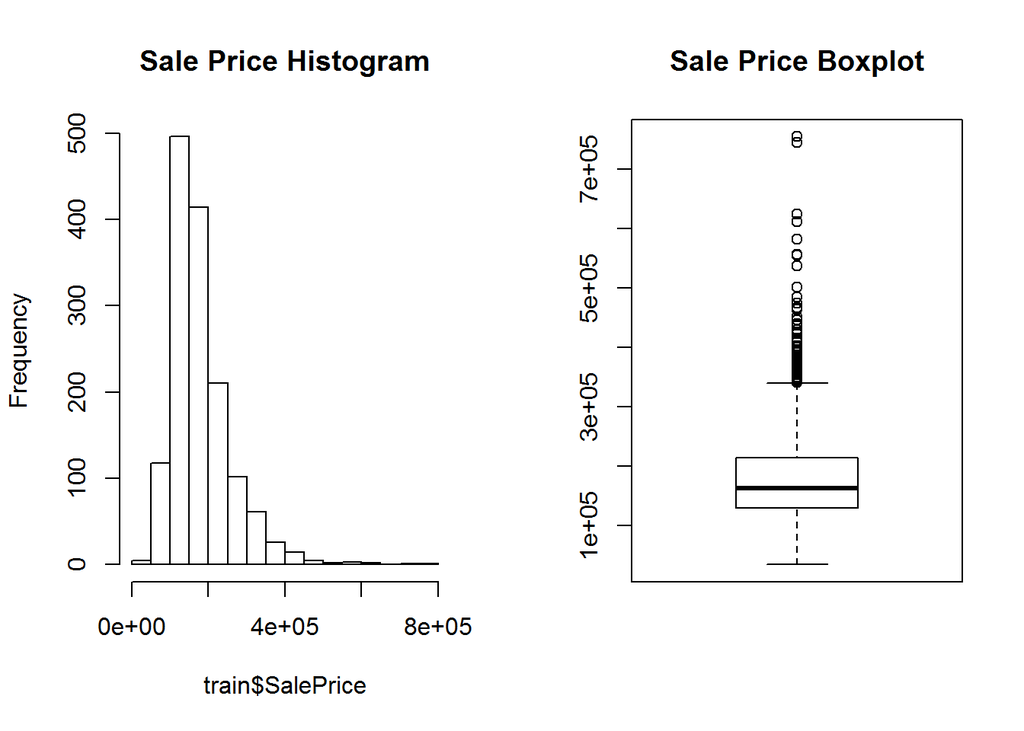

```r
par(mfrow=c(1,2))

hist(train$SalePrice, main= "Sale Price Histogram")
boxplot(train$SalePrice, main="Sale Price Boxplot")
```

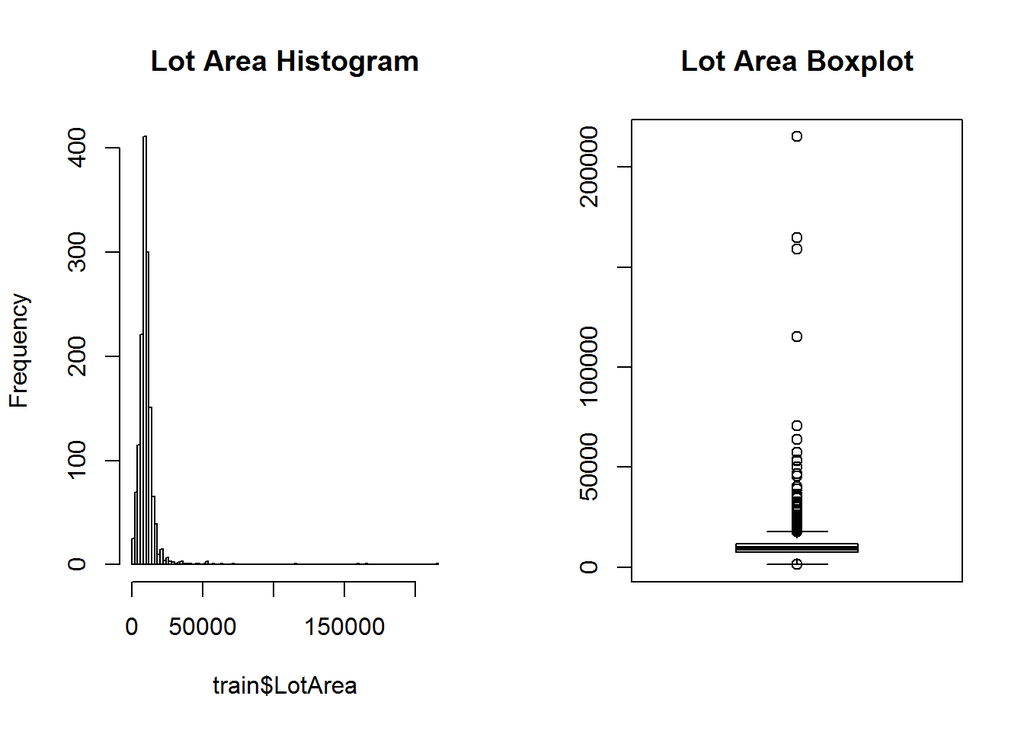

```r
hist(train$LotArea, breaks = 100, main="Lot Area Histogram")
boxplot(train$LotArea,main="Lot Area Boxplot")
```

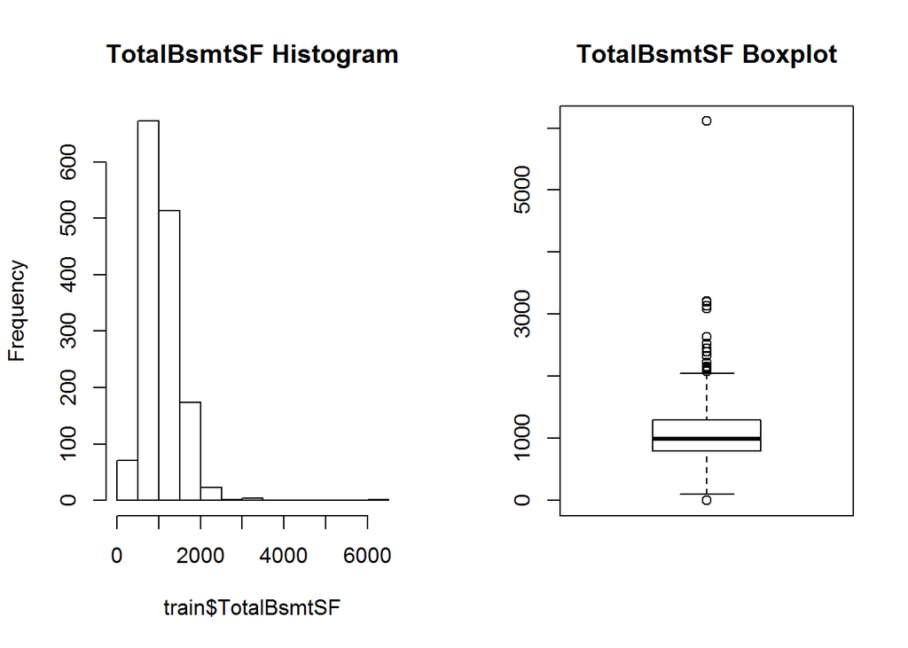

```r
hist(train$TotalBsmtSF, main="TotalBsmtSF Histogram")
boxplot(train$TotalBsmtSF, main="TotalBsmtSF Boxplot")
```

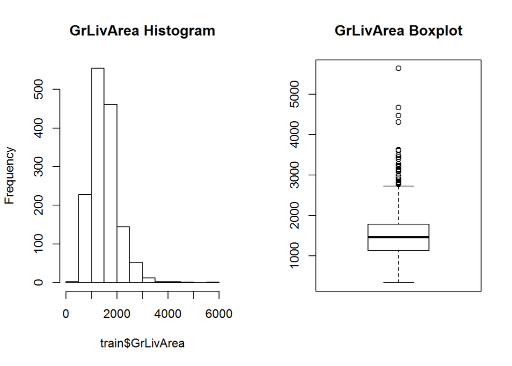

```r
hist(train$GrLivArea, main="GrLivArea Histogram")
boxplot(train$GrLivArea, main="GrLivArea Boxplot")
```

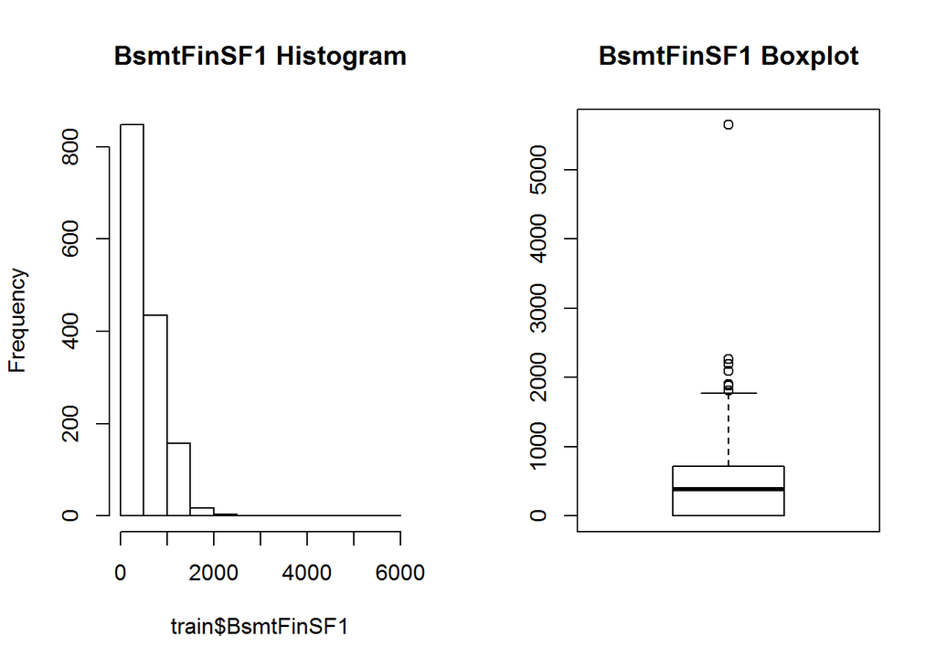

```r
hist(train$BsmtFinSF1, main="BsmtFinSF1 Histogram")
boxplot(train$BsmtFinSF1, main="BsmtFinSF1 Boxplot")
```

Scatterplot of X and Y (LotArea and SalePrice)

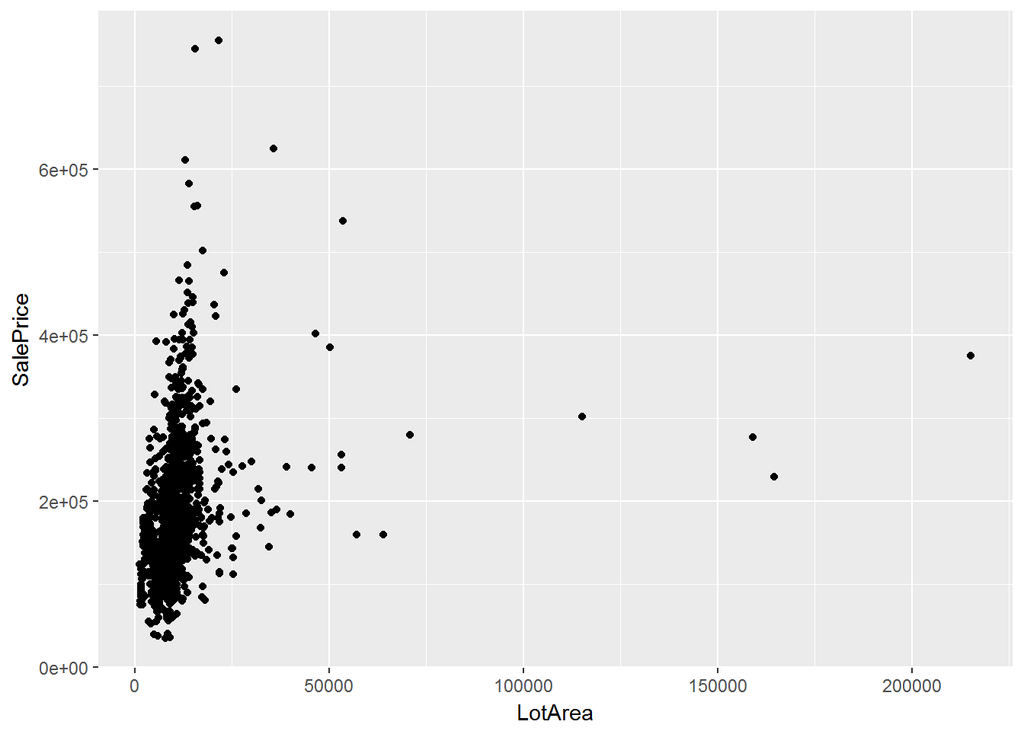

```r
p <- ggplot(train, aes(LotArea, SalePrice))
p + geom_point()
```

Test the confidence interval, the difference in means is not equal to zero, the alternative hypothesis (the two variables are dependent) must be accepted.

```r
t.test(X,Y)
```

```
##
##  Welch Two Sample t-test
##
## data:  X and Y
## t = -81.321, df = 1505.1, p-value < 2.2e-16
## alternative hypothesis: true difference in means is not equal to 0
## 95 percent confidence interval:
##  -174514.7 -166294.1
## sample estimates:
## mean of x mean of y
##  10516.83 180921.20
```

Correlation matrix

```r
correlation <- cor(X,Y)
correlation
```

```
## [1] 0.2638434
```

It is concerning that there is a weak correlation between these variables but it may be impacted by the outliers.

Test the hypothesis that the correlation between these two variables is 0 and provide a 99% confidence interval

```r
t.test(X,Y, conf.level = 0.99)
```

```
##
##  Welch Two Sample t-test
##
## data:  X and Y
## t = -81.321, df = 1505.1, p-value < 2.2e-16
## alternative hypothesis: true difference in means is not equal to 0
## 99 percent confidence interval:
##  -175808.7 -165000.0
## sample estimates:
## mean of x mean of y
##  10516.83 180921.20
```

Again we see the alternative hypothesis must be accepted.

Linear Algebra and Correlation. Invert your correlation matrix. (This is known as the precision matrix and contains variance inflation factors on the diagonal.) Multiply the correlation matrix by the precision matrix, and then multiply the precision matrix by the correlation matrix. Conduct principle components analysis (research this!) and interpret. Discuss.

```r
precision <- solve(correlation)
precision
```

```
##          [,1]
## [1,] 3.790128
```

```r
precision*correlation
```

```
##      [,1]
## [1,]    1
```

```r
correlation*precision
```

```
##      [,1]
## [1,]    1
```

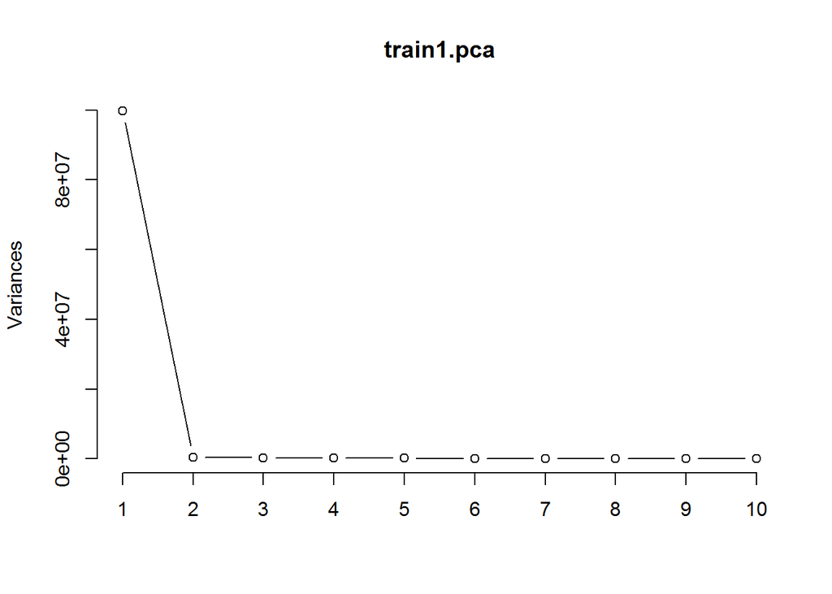

```r
train1 <- train[,-c(1, 3, 6, 7, 8, 9, 10, 11, 12, 13, 14, 15, 16, 17, 22, 23, 24, 25, 26, 28, 29, 30, 31, 32, 33, 34, 36, 39, 40, 41, 42, 43, 54, 56, 58, 59, 60, 61, 64, 65, 66, 73, 74, 75, 79, 80, 81)]

train1$LotFrontage[is.na(train1$LotFrontage)] <- median(train1$LotFrontage, na.rm=T)
train1$MSSubClass[is.na(train1$MSSubClass)] <- median(train1$MSSubClass, na.rm=T)
train1$MasVnrArea[is.na(train1$MasVnrArea)] <- median(train1$MasVnrArea, na.rm=T)

train1.pca <- prcomp(train1)
plot(train1.pca, type = "l")
```

```r
summary(train1.pca)
```

```
## Importance of components:
##                              PC1       PC2      PC3       PC4       PC5
## Standard deviation     9983.5604 653.07009 550.9416 501.04050 481.44900
## Proportion of Variance    0.9865   0.00422   0.0030   0.00248   0.00229
## Cumulative Proportion     0.9865   0.99076   0.9938   0.99625   0.99855
##                             PC6       PC7       PC8       PC9      PC10
## Standard deviation     2.14e+02 177.67066 151.77632 121.08186 114.46601
## Proportion of Variance 4.50e-04   0.00031   0.00023   0.00015   0.00013
## Cumulative Proportion  9.99e-01   0.99931   0.99954   0.99969   0.99982
##                            PC11     PC12     PC13     PC14     PC15
## Standard deviation     64.38507 58.31996 55.45334 53.20300 39.48635
## Proportion of Variance  0.00004  0.00003  0.00003  0.00003  0.00002
## Cumulative Proportion   0.99986  0.99989  0.99992  0.99995  0.99997
##                            PC16     PC17     PC18  PC19  PC20  PC21  PC22
## Standard deviation     38.97277 29.12368 24.50244 17.51 14.29 2.695 1.298
## Proportion of Variance  0.00002  0.00001  0.00001  0.00  0.00 0.000 0.000
## Cumulative Proportion   0.99998  0.99999  0.99999  1.00  1.00 1.000 1.000
##                          PC23   PC24   PC25   PC26   PC27   PC28   PC29
## Standard deviation     0.9761 0.9338 0.7931 0.5389 0.4929 0.4206 0.3767
## Proportion of Variance 0.0000 0.0000 0.0000 0.0000 0.0000 0.0000 0.0000
## Cumulative Proportion  1.0000 1.0000 1.0000 1.0000 1.0000 1.0000 1.0000
##                          PC30   PC31   PC32   PC33      PC34
## Standard deviation     0.3243 0.2803 0.2152 0.1728 4.434e-12
## Proportion of Variance 0.0000 0.0000 0.0000 0.0000 0.000e+00
## Cumulative Proportion  1.0000 1.0000 1.0000 1.0000 1.000e+00
```

```r
predict(train1.pca, newdata=tail(train1, 2))
```

```
##            PC1       PC2        PC3       PC4       PC5       PC6
## 1459 -810.1520 -737.3104  -15.01554 -40.02242 185.58805 -973.1410
## 1460 -578.3393 -421.3115 -607.15187  62.37828 -14.63047 -250.3169
##            PC7       PC8       PC9      PC10      PC11      PC12      PC13
## 1459 285.89987 155.28270 -472.4584 -176.0227  85.25565 -45.28279  15.04783
## 1460 -56.28094  20.45076 -603.9985  267.9792 -23.72223 -43.81752 -11.94615
##          PC14      PC15      PC16     PC17      PC18        PC19      PC20
## 1459 13.31498 -24.70145 -8.905269 8.530808 -19.28331   0.9980828  19.76756
## 1460 28.26637 -38.02561 -9.999947 3.807806  21.63278 -12.4356977 -13.22394
##            PC21       PC22      PC23       PC24       PC25       PC26
## 1459 -2.0695537  1.4265272 0.2743048 -0.8388139 -0.1351735 -0.2421546
## 1460 -0.5742693 -0.1432101 0.4730248  0.3938966  0.4124565 -0.4239340
##            PC27        PC28       PC29        PC30        PC31       PC32
## 1459 -0.4753415 -0.07347389 -0.1706407 -0.03898804  0.09377182 0.09529933
## 1460 -0.4098365  0.75193011  0.1873454 -0.16035366 -0.39308653 0.08625866
##             PC33          PC34
## 1459 -0.08682018  3.348993e-13
## 1460 -0.01231850 -3.297207e-14
```

```r
pdf <- fitdistr(X, densfun="exponential")
pdf
```

```
##        rate
##   9.508570e-05
##  (2.488507e-06)
```

```r
lambda <- pdf$estimate
lambda
```

```
##        rate
## 9.50857e-05
```

```r
evlambda <- 1/lambda
evlambda
```

```
##     rate
## 10516.83
```

```r
pdfsample <- rexp(1000, lambda)
pdfsample
```

[output not shown]

[output cut: 185 more lines]

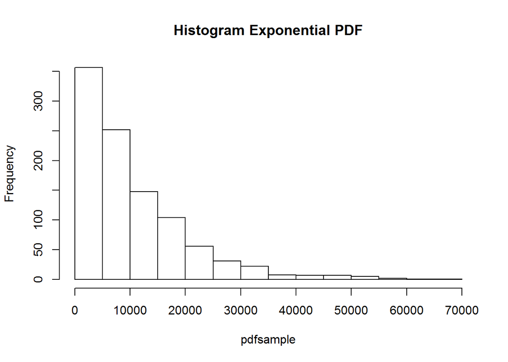

```r
hist(pdfsample, main="Histogram Exponential PDF")
```

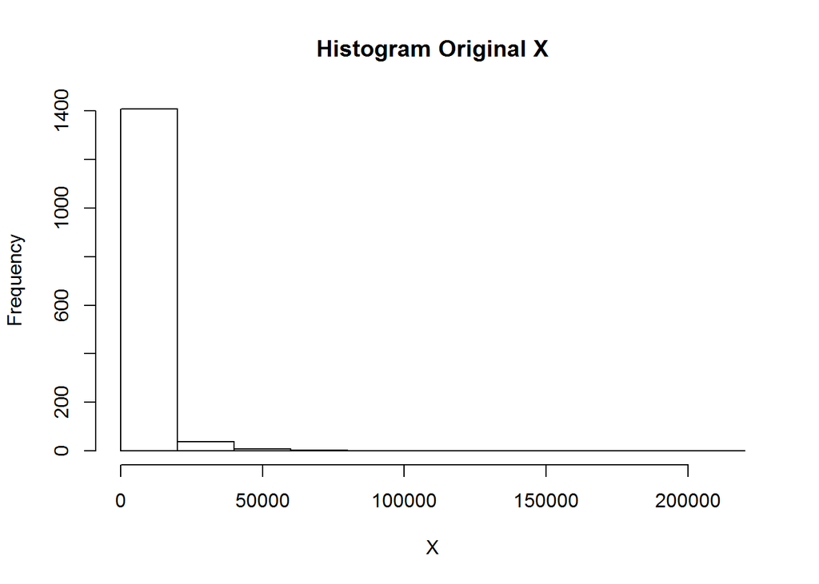

```r
hist(X, main="Histogram Original X")
```

The original X has more of a right skew than the exponential PDF.

95th percentile

```r
(-log(1-0.95))/lambda
```

```
##    rate
## 31505.6
```

```r
(-log(1-0.05))/lambda
```

```
##     rate
## 539.4428
```

```r
qnorm(c(.025, .975), mean=mean(X), sd=sd(X))
```

```
## [1] -9046.092 30079.748
```

```r
quantile(X, c(.05, .95))
```

```
##       5%      95%
##  3311.70 17401.15
```

Base Model

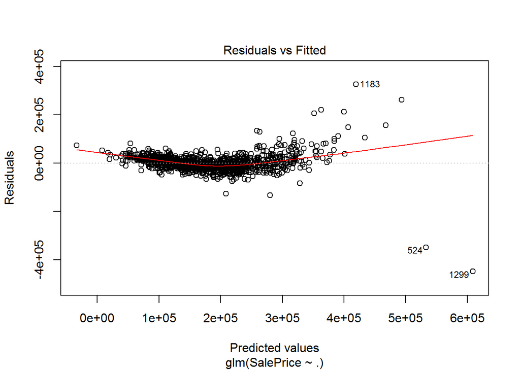

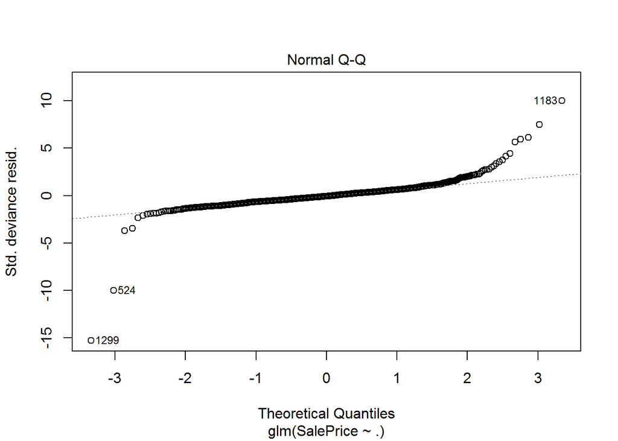

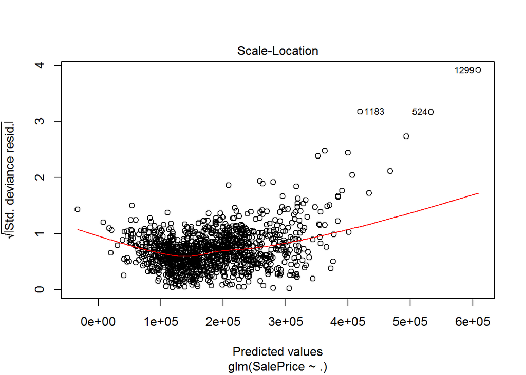

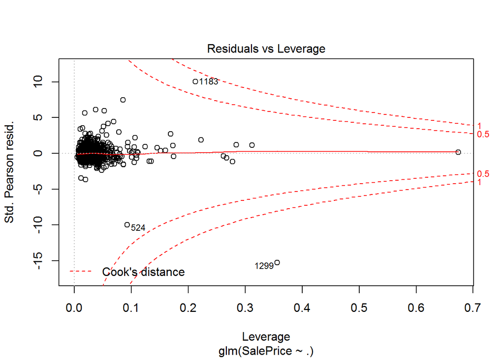

```r
train2 <- train[,-c(3, 6, 7, 8, 9, 10, 11, 12, 13, 14, 15, 16, 17, 22, 23, 24, 25, 26, 28, 29, 30, 31, 32, 33, 34, 36, 39, 40, 41, 42, 43, 54, 56, 58, 59, 60, 61, 64, 65, 66, 73, 74, 75, 79, 80)]

model0 <- glm(SalePrice ~ ., data=train2)
plot(model0)
```

```r
summary(model0)
```

```
##
## Call:
## glm(formula = SalePrice ~ ., data = train2)
##
## Deviance Residuals:
##     Min       1Q   Median       3Q      Max
## -448821   -17858    -2148    14186   325525
##
## Coefficients: (1 not defined because of singularities)
##                 Estimate Std. Error t value Pr(>|t|)
## (Intercept)   -4.044e+05  1.645e+06  -0.246 0.805868
## Id            -2.276e+00  2.548e+00  -0.893 0.372004
## MSSubClass    -1.903e+02  3.228e+01  -5.896 4.88e-09 ***
## LotFrontage   -8.966e+01  5.834e+01  -1.537 0.124608
## LotArea        5.506e-01  1.555e-01   3.540 0.000416 ***
## OverallQual    1.747e+04  1.394e+03  12.531  < 2e-16 ***
## OverallCond    4.271e+03  1.242e+03   3.440 0.000603 ***
## YearBuilt      2.986e+02  6.997e+01   4.267 2.15e-05 ***
## YearRemodAdd   1.744e+02  7.646e+01   2.281 0.022735 *
## MasVnrArea     3.501e+01  6.893e+00   5.079 4.41e-07 ***
## BsmtFinSF1     1.832e+01  5.531e+00   3.312 0.000956 ***
## BsmtFinSF2     7.534e+00  8.448e+00   0.892 0.372658
## BsmtUnfSF      7.619e+00  4.922e+00   1.548 0.121907
## X1stFlrSF      4.666e+01  6.978e+00   6.687 3.53e-11 ***
## X2ndFlrSF      4.604e+01  5.837e+00   7.888 7.04e-15 ***
## LowQualFinSF   3.443e+01  2.189e+01   1.573 0.116038
## GrLivArea             NA         NA      NA       NA
## BsmtFullBath   1.031e+04  3.020e+03   3.413 0.000665 ***
## BsmtHalfBath   2.485e+03  4.836e+03   0.514 0.607412
## FullBath       7.471e+03  3.288e+03   2.272 0.023246 *
## HalfBath       2.444e+02  3.134e+03   0.078 0.937858
## BedroomAbvGr  -1.016e+04  1.964e+03  -5.174 2.70e-07 ***
## KitchenAbvGr  -1.255e+04  5.827e+03  -2.154 0.031436 *
## TotRmsAbvGrd   5.134e+03  1.429e+03   3.592 0.000343 ***
## Fireplaces     4.498e+03  2.122e+03   2.120 0.034237 *
## GarageCars     1.137e+04  3.278e+03   3.468 0.000544 ***
## GarageArea    -1.882e+00  1.133e+01  -0.166 0.868152
## WoodDeckSF     2.410e+01  9.715e+00   2.481 0.013244 *
## OpenPorchSF   -1.624e-01  1.803e+01  -0.009 0.992815
## EnclosedPorch  1.111e+01  1.967e+01   0.565 0.572475
## X3SsnPorch     2.839e+01  3.728e+01   0.762 0.446461
## ScreenPorch    5.861e+01  2.014e+01   2.910 0.003688 **
## PoolArea      -6.473e+01  2.941e+01  -2.201 0.027915 *
## MiscVal       -2.327e-01  5.772e+00  -0.040 0.967846
## MoSold        -1.724e+02  4.053e+02  -0.425 0.670605
## YrSold        -2.911e+02  8.174e+02  -0.356 0.721810
## ---
## Signif. codes:  0 '***' 0.001 '**' 0.01 '*' 0.05 '.' 0.1 ' ' 1
##
## (Dispersion parameter for gaussian family taken to be 1337625674)
##
##     Null deviance: 8.2595e+12  on 1194  degrees of freedom
## Residual deviance: 1.5516e+12  on 1160  degrees of freedom
##   (265 observations deleted due to missingness)
## AIC: 28540
##
## Number of Fisher Scoring iterations: 2
```

Model with high estimate variables and significance

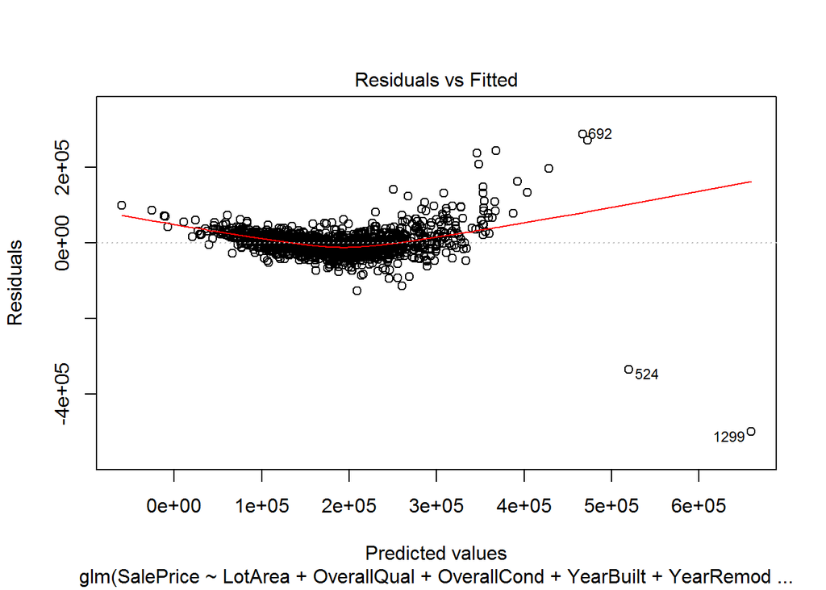

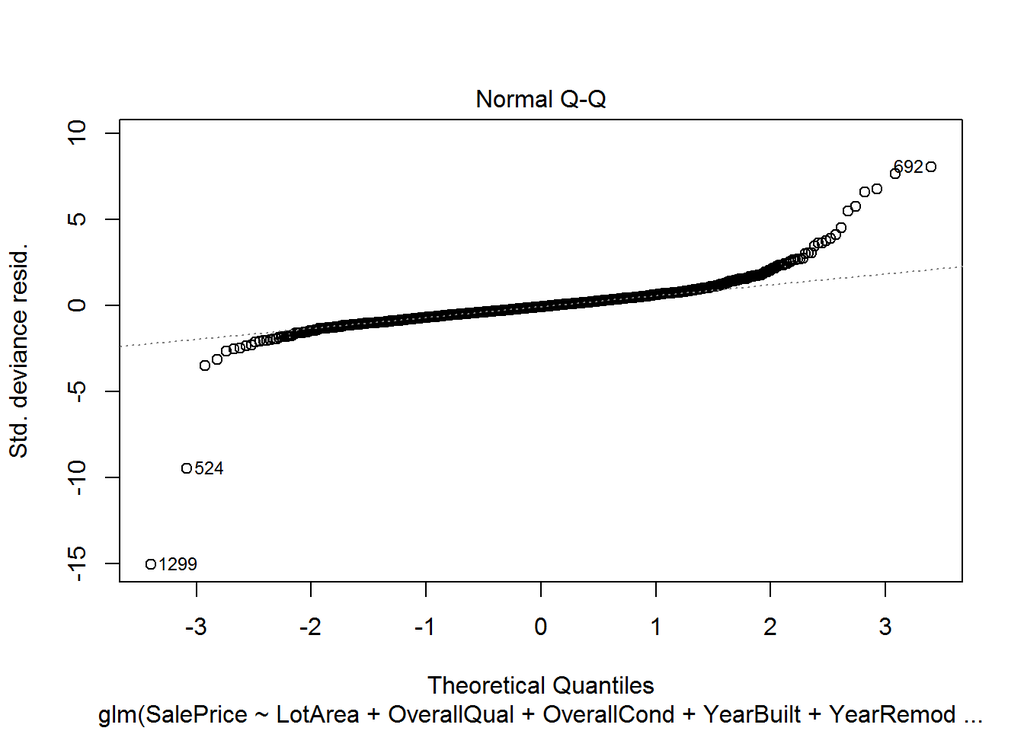

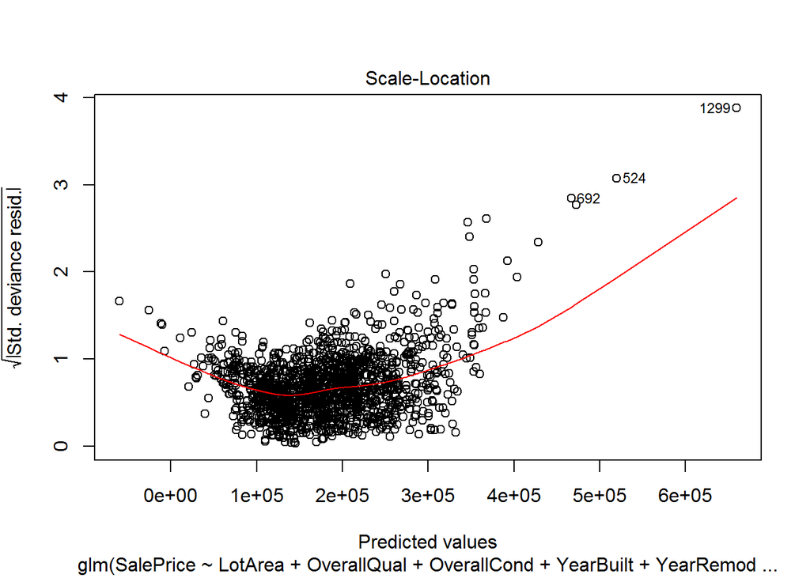

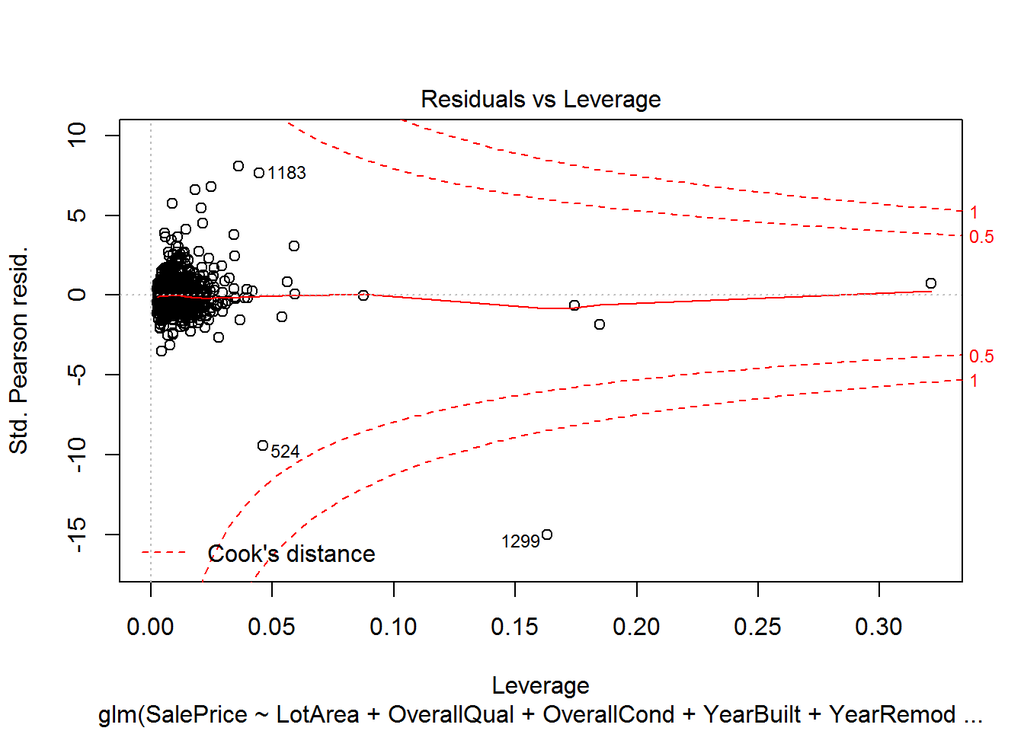

```r
model1 <- glm(SalePrice ~ LotArea + OverallQual + OverallCond + YearBuilt + YearRemodAdd + BsmtFinSF1 + X1stFlrSF + X2ndFlrSF + FullBath + TotRmsAbvGrd + + GarageCars + WoodDeckSF + ScreenPorch, data=train2)
plot(model1)
```

```r
summary(model1)
```

```
##
## Call:
## glm(formula = SalePrice ~ LotArea + OverallQual + OverallCond +
##     YearBuilt + YearRemodAdd + BsmtFinSF1 + X1stFlrSF + X2ndFlrSF +
##     FullBath + TotRmsAbvGrd + +GarageCars + WoodDeckSF + ScreenPorch,
##     data = train2)
##
## Deviance Residuals:
##     Min       1Q   Median       3Q      Max
## -499485   -17074    -2461    13843   288067
##
## Coefficients:
##                Estimate Std. Error t value Pr(>|t|)
## (Intercept)  -1.159e+06  1.251e+05  -9.261  < 2e-16 ***
## LotArea       5.253e-01  1.027e-01   5.117 3.52e-07 ***
## OverallQual   2.074e+04  1.123e+03  18.465  < 2e-16 ***
## OverallCond   4.114e+03  1.032e+03   3.987 7.03e-05 ***
## YearBuilt     3.236e+02  5.476e+01   5.910 4.26e-09 ***
## YearRemodAdd  2.113e+02  6.621e+01   3.191 0.001446 **
## BsmtFinSF1    1.913e+01  2.482e+00   7.707 2.38e-14 ***
## X1stFlrSF     6.139e+01  4.764e+00  12.887  < 2e-16 ***
## X2ndFlrSF     4.249e+01  4.147e+00  10.247  < 2e-16 ***
## FullBath     -2.724e+03  2.598e+03  -1.049 0.294506
## TotRmsAbvGrd  1.630e+03  1.070e+03   1.523 0.128012
## GarageCars    1.273e+04  1.748e+03   7.284 5.31e-13 ***
## WoodDeckSF    3.032e+01  8.165e+00   3.713 0.000213 ***
## ScreenPorch   6.111e+01  1.743e+01   3.506 0.000469 ***
## ---
## Signif. codes:  0 '***' 0.001 '**' 0.01 '*' 0.05 '.' 0.1 ' ' 1
##
## (Dispersion parameter for gaussian family taken to be 1318834082)
##
##     Null deviance: 9.2079e+12  on 1459  degrees of freedom
## Residual deviance: 1.9070e+12  on 1446  degrees of freedom
## AIC: 34819
##
## Number of Fisher Scoring iterations: 2
```

Predict House Price

```r
predict <- predict(model1, test, type="response")
predict
```

[output not shown]

[output cut: 433 more lines]

[output not shown]

```r
results <- data.frame(test$Id, predict)
colnames(results) <- c("ID", "SalePrice")
#write.csv(results, file = "submission_predicted_prices.csv", row.names = FALSE)
```